# Lecture 12: Now That You Know Everything, Communicate It!

# A Lecture in Parts

- Part I: Communication
- Part II: Aiming for Success
- Part III: Ethics in Data Science
- Part IV: Wrapping Up the Class
- Part V: Some Life Lessons

# Part I: Communication

- Maybe we **don’t really know everything** about data science after one semester – or 15 years.
- However, every project reaches a point at which you now **know a lot** about the problem, the data, and the analysis.
- In most settings, your results are **only important if they are communicated** in a way that leads to actions.

# The Usual Advice About Communication

Most data science classes will offer good but simple advice about communication:

- **Data visualizations** can be an excellent way to communicate your findings to others.
- Generating **simple results** like means, percentages, and predictions will usually be more comprehensible to outsiders.
- **Talking about your work** requires some selectivity in presenting the depth of the technical details.

# But There’s More to Communication – A Lot More

- We have spent **our entire lives** learning how to communicate.
- In spite of that, **we can all do a better job** of it.
- Like any other skill we’ve learned, there are **frameworks and methods** that can help you improve.

# I’m Not an Expert

- Today’s discussion will be based on my own observations built up over a wide variety of working experiences.
- However, I can offer **no special secrets or advice** that will transform your communication skills.
- Instead, I want to focus on the **settings and situations** that can make communication challenging and help you to **understand the process** by which you can observe and improve your abilities.

# Communication (Still) Rules the World

- Decisions are still made **based upon authority** as much as data.
- Data science offers an avenue to **change the course** of an organization’s plans.
- However, it’s **not enough to do the work**. To make a difference, you have to communicate your results.

# The Expectations are Changing

- When I was a student, statisticians were **not necessarily expected** to work so closely with interdisciplinary teams.
- The new wave of data scientists is bringing in a **greater diversity of talents** and **collaborating in novel ways**.
- With changing expectations, the **value of communication skills** within data science is only growing.

# A Technical Sphere of Communication

- A Chief Data Scientist once provided me with one big company’s view of how its Data Science department would interact with the rest of the company:

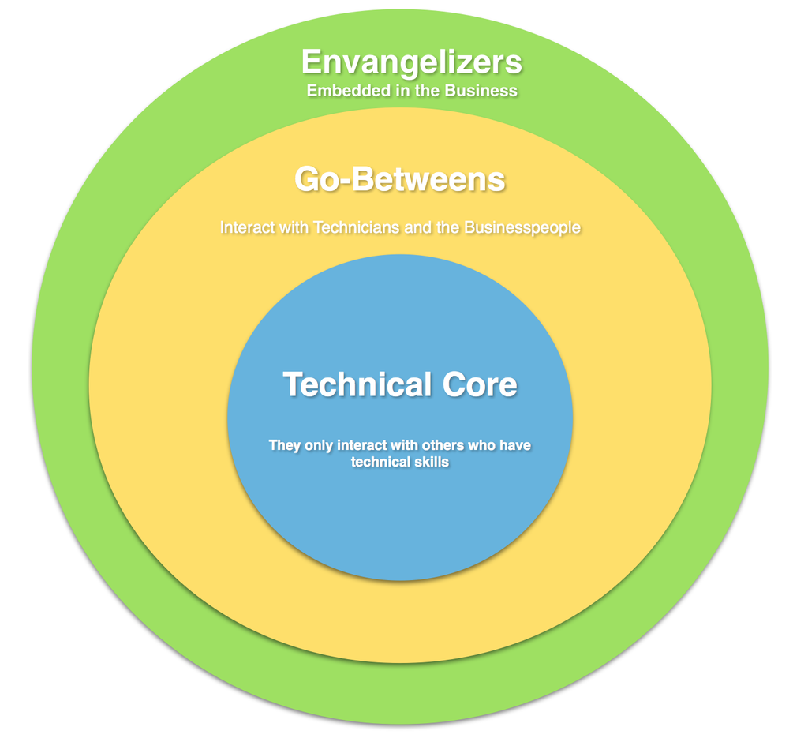

# Not the Only Way

- The design of the organization and its **conduits of communication** will vary widely from place to place.
- In the case of the big company, the **evangelizers** (not a great term, but this is what they’re called) were senior managers who could fully navigate the business and were **highly persuasive** in convincing the businesspeople to incorporate the analyses.
- The evangelizers were also **paid much more** to persuade people to use the results **than the data scientists who produced the results**.

# The Other Half of Your Job

- Producing changes requires **doing the analysis** and **making decisions** that incorporate it.
- **Educating others** about what you’ve found and **persuading them to take it seriously** are just as important as getting the results.
- Unfortunately, you probably **don’t get to devote half of your time** to communication.
- What does this mean? You have to be **more productive with communication** than you are with data science!

# What Is Communication, Exactly?

- Communication is **sharing information** with others.
- Anything you **do, write, or say** is communicative in some way.
- Communication can be **formal or informal**, delivered in **any style** that gets a message across.

# You’re Not the Judge

- For better or worse, the quality of your communication depends a lot on your ability to **connect with your audience**.
- No matter how **deftly you deliver** your message, it may still **fall on deaf ears**. Your audience will judge what they hear on their own terms.
- The reasons for this can be **outside of your control**, but it’s still fair to say that effective communicators **have a greater influence** on their audience than others.

# Code Switching

- Each person has their own **unique preferences** for communication.
- **Code switching** is the act of switching between different styles of communication based on the setting.
- You **talk to your friends** differently than you **talk to your manager**.

# The Setting and the Audience

- There are **formal and informal** settings to communication.
- There are **small, medium, and large** audiences, all with different degrees of **prior knowledge**, **cultural expectations**, and **willingnesses to listen**.
- There are **short, medium, and long** presentations.

# Different Modes of Delivery

- Written
- Oral
- Visual
- Multimedia

# Your Choice – Sometimes

- There are **numerous modes** of communication with every possible variety of settings, audiences, and presentations.
- Where possible, you can **choose the manner** in which the information is conveyed.
- However, the setting and audiences are **not always up to you**. It is important to **adapt** to the setting.

# The Best and Worst Advice

- Everybody always says to **be yourself** with regard to communication.
- In some sense, that’s the **best advice**. It’s the only way for you to be comfortable.
- On the other hand, it’s the **worst advice**, because we are all a mix of our strengths and weaknesses. Making no changes will do nothing to make improvements or address the concerns that led to the request for guidance in the first place!
- My alternative: **Be the version of yourself that you think you can be**, and find a way to get there.

# Adjusting Your Communication

- **Mirroring** the behavior of others can help you connect with them.
- Employ **variation** in the complexity of the messages.
- Change your style!

# Not Too Little, Not Too Much!

- If you **don’t** adjust your communication **enough** to your audience, then it can be **difficult to connect** with them.
- If you adjust your communication **too much**, then your actions may be perceived as **pandering**, trying too hard, or possibly even offensive.
- The best thing you can do is **try to connect** with your audience, but don’t work too hard to get there.

# Show That You’re Listening

- While you’re presenting, it helps to **observe your audience**.
- **Reacting to clues** in their responses will give you opportunities to **adjust your delivery**.
- Better yet, **acknowledging earlier questions** can build continuity in your presentation. When a presentation returns to the subject of an earlier question, I try to directly engage with the person who asked that question.

# Noticing Clues

- Non-verbal communication
- Facial expressions
- Signs of interest or disinterest

# Feedback Informs the Next Presentation

- Use the responses you received previously to **change your next round of interaction** with a similar audience.
- Of course, you could **collect data** on all of this.
- But you might also choose **not to collect formal data** or to **use it in a different way**. Developing your communication skills requires enhancing a different form of intelligence that might be enhanced with different processes.

# Doublespeak and the Yeah Definitelys

- In my own personal observation, many people use the word **definitely** when they really mean **absolutely not**.
- Navigating settings that include **doublespeak** can be quite uncertain. You can’t know whether what you’re hearing is true, but you also can’t fully act as if it’s false, either!
- Worse yet, at various points in our lives, **people we know or work with are going to lie** to us or try to take advantage of a situation.
- While you can’t avoid every issue, your ability to communicate and infer the true motivations of others will go a long way toward helping you handle difficult situations as they arise.

# Waving My Glasses Around

- From time to time, I am asked to represent organizations for **external meetings**, which may include helping to negotiate deals.
- In these settings, my role is to **establish the expertise** of the organization: we have **rich sources of data**, employ **machine learning** to refine our processes, and a capable **data scientist** on staff who can make things happen.
- I jokingly refer to this process as **waving my glasses around**. At the end of the day, these presentations are meant to persuade business partners or investors without necessarily getting into the details. That turns out to be an important part of developing the business **so that you can actually do the work**.

# Communication is Challenging, But You Can Succeed

- With greater experience, you will improve in your communication over time.
- Better yet, this will **enhance** all of your tremendous methodological and technological skills.
- Moreover, **you can decide** the degree to which communication is an important part of your development.

# Part II: Aiming for Success

- What makes a data scientist successful?
- What will make you individually successful?
- How can your decisions, now and in the future, impact your path?

# Happiness and Satisfaction

- **Happiness** is a feeling that things are going well.
- **Satisfaction** is a feeling of accomplishment.
- In my view, **happiness is spending time in the company of your friends while doing nothing**. It can be quite momentary and difficult to sustain without some external support.
- Meanwhile, in my view, **satisfaction is a long-term feeling of contentment**. It results from a series of interconnected actions over a period of time.
- In reality, we need **both happiness and satisfaction**, but they are achieved in different ways over time.

# Why Do We Work So Hard?

- In some sense, **we have to** work so hard. That’s the way our economic system has been set up.
- External judgments of your **professionalism and dedication** can be just as important as the **results**.
- We end up working so hard because that’s what everyone else is doing.

# The Rewards of a Job Well Done

- Unfortunately, many organizations reward good work **by giving you more of it**.
- This creates **poor incentives**. You won’t necessarily receive a greater salary for doing well.
- Ultimately, poorly designed incentives lead to **dissatisfaction and stagnation**.

# A Different Way

- The skills you have learned in this class may help you to work **more productively and effectively**.
- Your abilities may or may not be utilized effectively by the organizations and teams around you.
- When you see these disconnections, it is **up to you** to either **change the way** your team operates or to **find a new situation** that is more in line with your aims.

# Finding your Strengths

- Data science can require **numerous skills** to be successful.
- However, you **do not have to be good at everything** to be successful.
- Your own exploration should be about **understanding and developing your strengths**.

# Cultivating Self Awareness

- It is hard to succeed without having a full appreciation for **who you are** as a person, your goals, and what you’re willing to do to achieve them.
- Self awareness develops over time.
- Without enough self awareness, your actions can have **unintended consequences** – or even lead you to make choices you otherwise would not.
- Taking the time to cultivate this understanding can be a **great investment** – from both a personal and a professional point of view.

# A $5,000 Challenge

- Suppose you suddenly had an **extra $5,000** (or some other arbitrary amount of money) in your pocket.
- Over the course of one year (or some other arbitrary amount of time), how would you **spend that money** to **make your life better**?
- Since you may soon have a higher salary and more of a discretionary budget, it’s a good question to ask. Saving money is also important, but there may be things you can **do right now** that would be better than what saving would accomplish later.

# The Answers I Heard

For a period of time, I went around asking my friends to solve their $5,000 Challenge:

- Some friends wanted to **pay off their debts**. This is laudable, but it struck me as solving longer-term issues rather than shorter term ones.
- Other friends wanted to **donate the money** to a good cause. This is also laudable, but it struck me as a momentary approach to being happy instead of building longer-term satisfaction.
- An acquaintance changed my life when he said: **I would spend that money on laundry**. He identified laundry as the greatest avoidable use of his time. By spending money on a service, he would give himself a few more hours a week to do what he really loves – reading books.

# A Major Change

- Time is your **most valuable resource**.
- If money can help you make better use of your time, it is often a **tremendous investment**.
- The extra time can be used on **anything that you want**. This could lead to **greater enjoyment** or opportunities to **make a greater salary** than you otherwise would have.

# Enhancing Empathy

- As you develop your own self awareness, it also helps to develop your understanding of the people around you.
- Empathy without understanding can lead to hurtful actions.
- No matter how talented you are, **success is a team effort**. Finding ways to help others can be good for everyone.

# What Motivates People

It’s rarely one thing, but it may be some combination of:

- Achievement
- Fitting in with others
- Power
- Curiosity
- Status
- Appreciation
- Serving Others

Developing this awareness of how others perceive themselves can help you craft your message – and perhaps help you steer others toward achieving your shared goals.

# Beware of Power Seekers

- From time to time, I’ll meet a new person who will quickly attempt to **establish dominance** in their relationships. They will say something offensive or personally insulting, usually with an expression that suggests they’re attempting to be humorous. It’s also clear that they are presenting me with some kind of choice.
- If I **react negatively** (which would be entirely appropriate), then I am **giving them the power** to continue offending me. They’ll know how to press my buttons.
- If I **play along** (which is at times necessary even if it’s not ideal), then I am **also giving them the power** to set the agenda. They’ll feel validated that I didn’t disagree with their point of view and perhaps even believe that I am like-minded.

When confronted with a game that you can’t win, there is little gained by trying. Instead, the best thing one can do is **hold your ground** without reinforcing the other person’s point of view.

# Beware of Well-Meaning Advice

- At other points in time, I have received some well-meaning advice from coworkers and managers that, in my view, was not very helpful.
- I ultimately realized that this advice came from a standpoint of wanting me to be better at their version of my job.
- This ultimately led me to realize that my vision for my career and development was quite different than theirs, and that these coworkers and managers were not trying to help me to achieve those goals.

# Developing Your Own Power

- You can’t always choose the settings or the people around you.
- However, you can choose what you allow others to ask of you, what you’ll accept, and what you’ll walk away from.
- Navigating the existing power structures may present a neverending series of obstacles and arbitrary rules.
- Instead, the best thing you can do is to **build your own power structures** with all of the decisions you make.

# Using Your Power for Good

- Those who **work their way up** the power structure **tend to reinforce the existing structures**.
- This may be good for you, but it **may not be so good for the others** – very much like you – who did not advance.
- It’s not enough to develop power, it also has to be applied toward good purposes. This means changing the way things work, **not just for you** but also for **those around you**.

# What You Like and What You’re Good At

- You can guide your career in many directions.
- Some people do what they like, and others what they’re good at doing. Occasionally you get to do both, and sometimes you have to do something else.
- However, even if you’re not immediately doing what you’d like to do, it can still be helpful if it leads somewhere.

# Where It All Leads

After a long journey, I ultimately settled on two goals for myself:

- Exploring my own capacity to accomplish things, and
- Finding ways to help others as much as possible.

While this has taken many forms over time, those goals tend to underpin what I do and the decisions I make to get there.

# Successful People are Simple People

- Most successful people I’ve encountered have **established routines** for how they do their work.
- They also **eliminate distractions and obstacles** that get in the way of achieving success.
- After that, they **get to work**. There really isn’t anything more to it than that.

# But Success Isn’t Everything

- External measures of success – salaries, titles, status symbols – can be nice, but they’re not everything.
- Many factors are outside of your control, and luck plays a major role in our outcomes.
- Moreover, many people who are considered successful **don’t actually do anything to make life better**. The impact of your career goes beyond the balance sheet.
- Regardless of that, your own sense of **satisfaction and happiness** will ultimately be more important than whether you are deemed a success by others.

# A Reading List

- Virginia Eubanks: **Automating Inequality** https://us.macmillan.com/books/9781250074317
- E. Anderson: **Private Government** https://press.princeton.edu/titles/10938.html
- D. Graeber: **Debt: The First 5,000 Years** https://www.goodreads.com/book/show/6617037-debt
- D. Thompson: **Workism is Making Americans Miserable** https://www.theatlantic.com/ideas/archive/2019/02/religion-workism-making-americans-miserable/583441/
- C. Mark: **A Belief In Meritocracy is Not Only False: It’s Bad for You** https://aeon.co/ideas/a-belief-in-meritocracy-is-not-only-false-its-bad-for-you
- M. Rogati: **How Not to Hire Your First Data Scientist** https://hackernoon.com/how-not-to-hire-your-first-data-scientist-34f0f56f81ae

I am suggesting these works not to necessarily advocate a point of view but to provide strong examples of interdisciplinary work that use information and analysis to upend the conventional wisdom.

# Part III: Ethics in Data Science

- Your work can have a big impact on people’s lives, businesses, and choices.
- Data scientists can be the guardians of honest inquiries and good decisionmaking.
- You have a responsibility to uphold high standards of ethics in your work.

# Be Right (or Wrong) for the Right Reasons

- Variation leads to uncertainty in our estimates.
- Because of uncertainty, you can be right or wrong for the **right or wrong reasons**.
- You can’t control the outcome of a random process, but you can control the decisions you make. Make sure they rely on the best data and analyses.

# And Be Honest

- **Your example** can impact the entire organization.
- The technological tools at your disposal enable you to process and learn from an unprecedented degree of information. **Use those powers honestly and for good purposes.**
- You also have the power to **improve the standards** of accountability, transparency, and reproducibility of your work.

# Part IV: Wrapping Up the Class

We’ve come a long way! Now let’s take a small victory lap to remind ourselves of what we set out to do.

# What Data Science Is All About

[figure not shown]

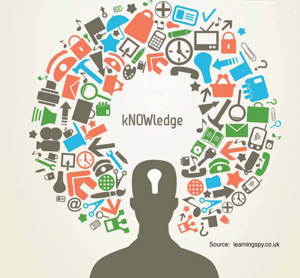

[figure not shown]

# But There’s Usually More To It

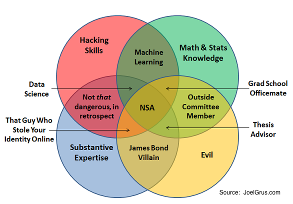

# Seeking Knowledge

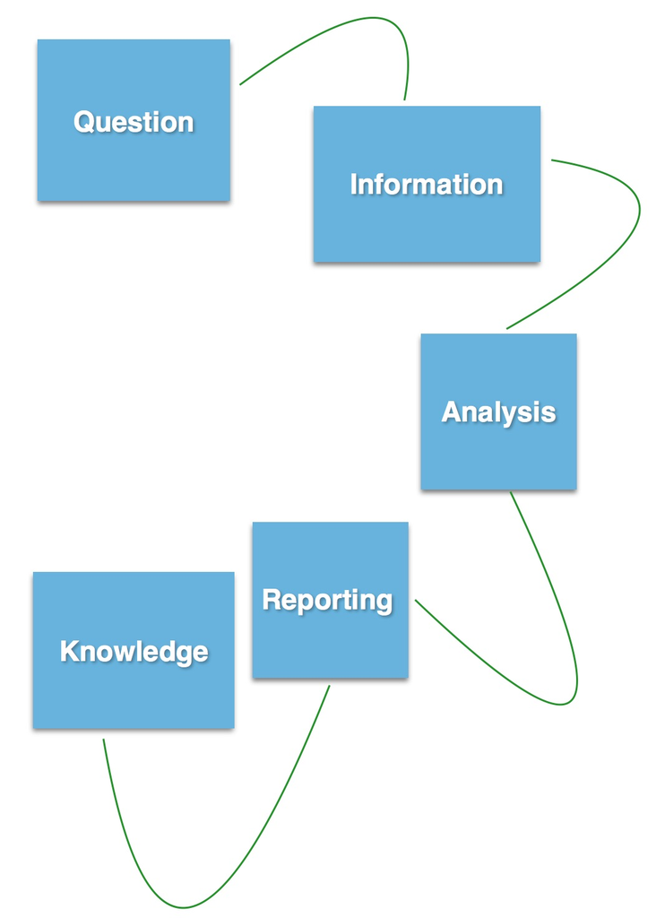

# What It’s Really Like

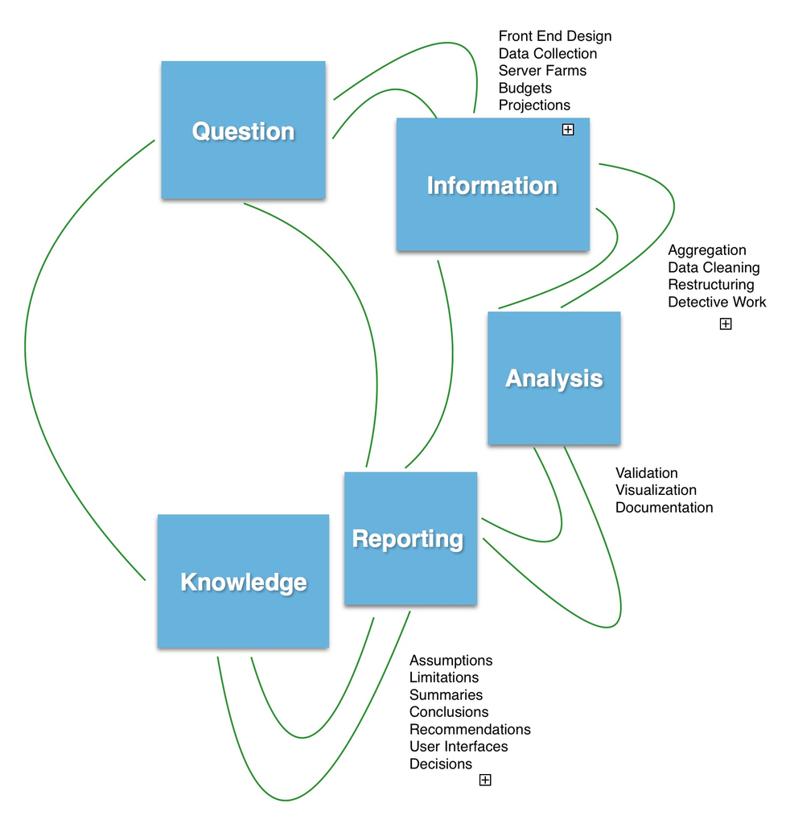

# And Don’t Forget About The People

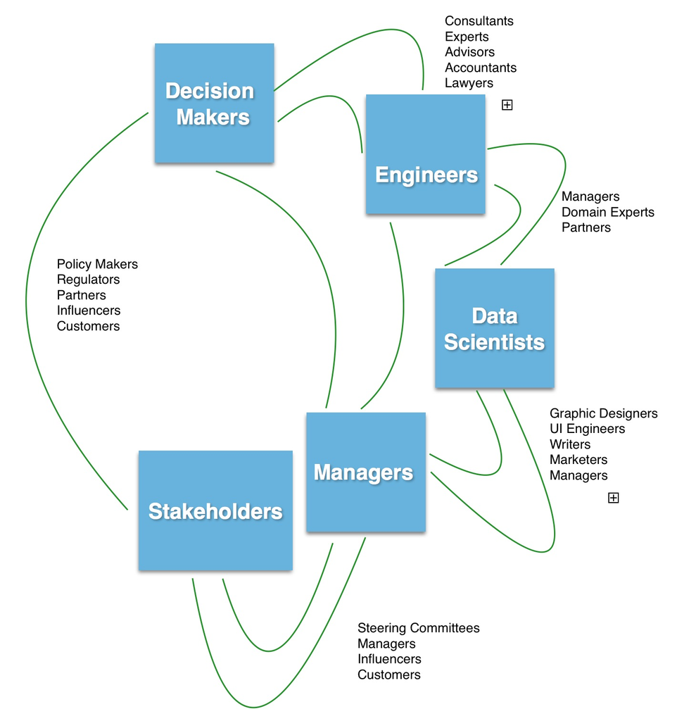

# Data Science Has Its Own Challenges

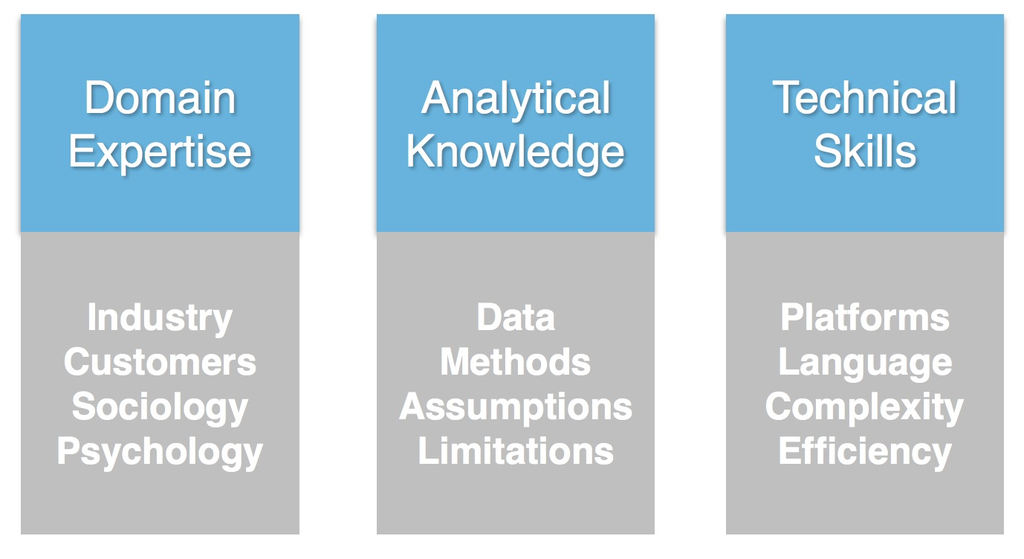

Many projects require very specific combinations of these skills. No one is a master of everything, but having a vision for your development can help immensely.

# Don’t Say I Didn’t Warn You

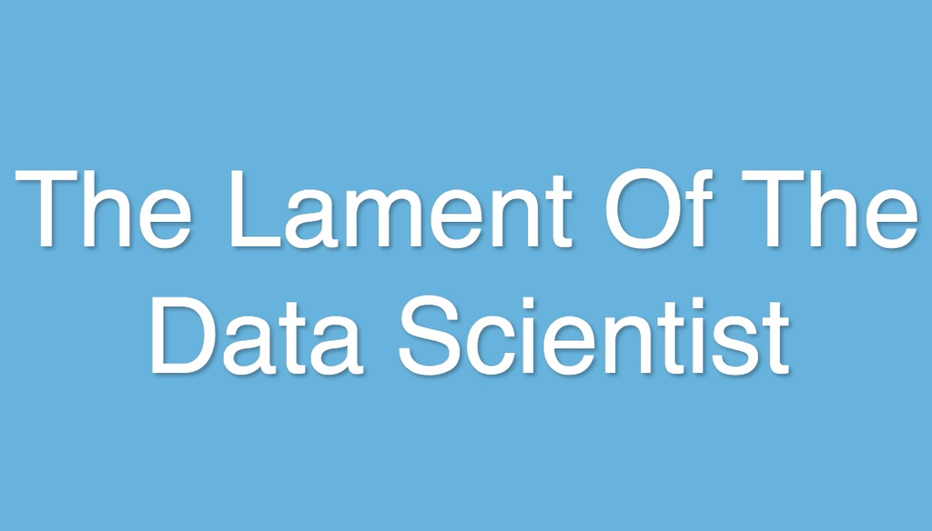

“80-90% of my time on a project is spent on cleaning up messy data sets. I would really like to spend more time doing analyses.”

– Origin: Every data scientist out there.

# Yes, But Data Cleaning Is Important

- You can’t generate good results without good data.
- You can’t understand your data without understanding the mess it came from.
- Your detective work can improve many facets of the organization and reduce many of its risks.
- If good decisions are based on good data, then you become the guardian of the whole process.

# Better Yet, Opportunities Abound

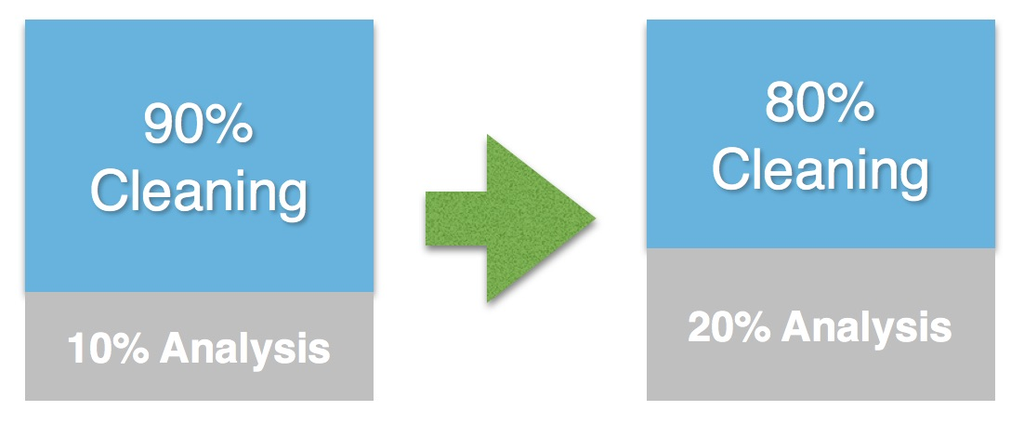

If you can improve your efficiency in data cleaning by just over 10%, you can **double your capacity** for analysis.

By honing your technical skills, **performance improvements of an order of magnitude** or more are within reach.

# What This Course Is All About

“When I was your age…”

- I had a limited sense of how analytical methods could be applied.
- I was much less aware of the challenges of this work.
- More generally, we lacked the technical sophistication of today’s tools.

I hope this course has provided you with some additional perspective about data science and help to prepare you for the opportunities that lie ahead.

# Goals For The Semester

- Create a fast track for developing your expertise with R.
- Enhance your abilities to clean, organize, and understand data.
- Gain experience with the basic methods of data analysis.
- Develop some intuitions about statistical models.
- Learn how to interpret the results of analytical work.
- Learn how to *communicate* the results of analytical work.
- Explore the practice of data science across a variety of industries and applications.

Check, check, …, check. We did a great job!

# How We Got There

- Intensive R training.
- Exploration of different industries.
- Introduction of methods and techniques *in context*.

Through hard work and curiosity, we have all come a long way this semester!

# Grades: I Have to Assign Them

- For better or worse, it’s part of my job to evaluate your performance in the class.
- This evaluation is not personal.
- Your **grades do not necessarily reflect your overall growth** because they depend a lot on your prior knowledge.
- Additionally, as statisticians we all know that grades result **from a random process**. I take this uncertainty into account in making my decisions.
- Finally, I **invest time in reviewing your cases** and try to ensure that your grades reflect a **positive view** of your performance. If you ask me later for a higher grade, it’s highly likely that I already did so by considering the merits of your case.

# Thanking the Teaching Staff

- In office hours, grading, and behind the scenes, the teaching staff did an excellent job.
- I would especially like to thank them for making extra efforts to engage with all of you.
- This work was beneficial for the class and also enabled me to focus on the areas that I felt would be the most effective.

Thank you very much!

# Thanking You

- This class was meant to go beyond the usual curriculum for this subject.
- To get there, I almost certainly asked you to worker much harder than a usual class would. If you feel like you learned a lot, it’s because you did the work to get there! As an educator, I can’t ask for more than that.
- And overall, I really enjoyed all of the lectures, discussions, e-mails, and opportunities for growth. I have also learned a lot from the experience, and it’s truly been a pleasure to work with you.

Thank you very much!

# Behind the Curtain

- This class has been an excellent test of whether my personal model of teaching would scale up to a much larger volume of students than I’ve previously worked with.
- I also envisioned running this class as a test of what it would be like to lead an organization of this size.
- You’ll find in life that we get relatively few opportunities to really do something our way, with quite a bit of control over the content and intended experience. Developing this class has been one of those moments for me.

# Keeping In Touch

- I would be delighted to stay in touch.
- Beyond that, you might be surprised by the opportunities to collaborate down the road.
- Feel free to reach out from time to time. I like to hear about what happened down the road.

# Part V: Advice for Life

- No matter what I’m teaching, I always like to close with some points of wisdom that have been helpful for me and might be beneficial for you.
- Being successful in your career – and satisfied with your life more broadly – often involves more than just doing good work.
- I may not be the right person to offer advice, but here goes…

# Lesson 1: It’s Your Life

Our society has its own expectations for what a happy, successful life looks like. However, it’s really up to you.

- Set your own priorities.
- Work in the areas you want to work in.
- Make your choices based on what you want rather than the expectations of others.

# Toward Independence

- Your life up to this point has benefitted from the guidance of your families, teachers, friends, and supportive organizations.
- Most of that guidance was meant to get you to where you are today.
- There may not be a model for where you want to go next. That’s why it’s up to you to understand yourself and shape your life accordingly.

# Career Distribution

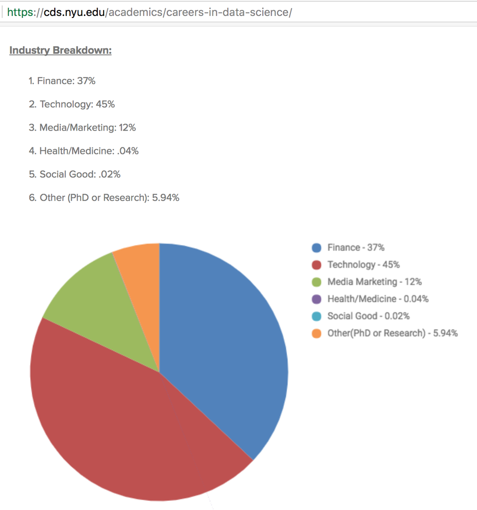

This may be a reflection of what jobs are available or pay the best. However, there’s nothing stopping you from choosing an alternative career path – or finding ways to make more money doing that. If you are creative, it’s certainly possible to improve upon what even a very competitive job would offer you.

# Lesson 2: Set a Vision

- Create a sense of your goals in the short, medium, and longer terms
- Develop plans for achieving those goals. Even the longer term interests require concrete actions in the short term to get there.
- Be flexible and willing to adjust your plans.

# Lesson 3: Maintain High Standards for Yourself

- Develop a sense of self-awareness.
- Seek out opportunities for improvement.
- Be willing to do what it takes to get where you want to go.

# Lesson 4: Be Picky

- Certain choices (e.g. a job) lock you into a direction for some period of time.
- Making good choices can get accelerate your progress; poor choices can take you in the wrong direction.
- Don’t settle for adequacy if it’s not serving your long term interests.

# Lesson 5: Speak Up

- The typical meeting: 8-10 people in a room, with only 2-3 who ever speak.
- It may not always be appropriate to speak up. However, contribute wherever you can.
- Likewise, if something is going wrong with your project or work, the best thing you can do is to bring it to the attention of others.

# Lesson 6: Figure People Out

- Most of your job is about making someone else happy: a manager, customer, partner, etc.
- Most people have their own stressful jobs and lives.
- Being able to communicate effectively can be just as important as any technical work you might do.

# Lesson 7: Figuring Out Your Manager

For better or worse, most organizations operate in a fairly hierarchical structure. In that setting, your working relationship with your manager can drive your success. Figuring out your manager’s needs and abilities can help you do good work.

- Change your communication based on how much detail your manager wants or needs.
- Anticipate the kinds of questions your manager might ask. Perform that kind of review ahead of the meetings.
- If your manager doesn’t understand analytics, be careful about how they get involved in your work. Some managers would rather be in charge of the wrong analysis than get it right. You’ll have to choose how to handle these situations carefully.

# Lesson 8: Be Professional

- Plan ahead and get started early.
- Limit distractions.
- Create the image of an earnest and hard-working collaborator. Then make sure that your work backs up that image.

# Lesson 9: Don’t Wait Too Long

- Not every working environment is the right situation.
- If your job is stressful, it won’t magically get better.
- A new job means more money and a better environment.

Big decisions require a certain degree of deliberation to get it right. But don’t wait too long!

# Lesson 10: There’s More to Life Than Working

I hope that you will find a career path that leads to success and satisfaction. However, that’s often easier said than done. Along the way, you may need to make some sacrifices. Sometimes that’s OK, but don’t forget about all of the other aspects of your life that deserve time and attention:

- Family and friends;
- Your health;
- Hobbies and interests;
- Relaxation and enjoyment.

Over time, your priorities may change. It’s OK to modify your career plans accordingly. But this will only result from your own concerted effort.

# Conclusion

- I’ve been quite satisfied with your progress this semester.
- It can be difficult to get started with new methods, programming languages, and applications. If learning data science is like learning to fly an airplane, then we have successfully achieved lift-off.
- Now it’s up to you. I wish you all the best!